# hw02-Tang-Jiahui

Jiahui Tang

2017/9/22

## Load Packages

```r
library(gapminder)
library(tidyverse)
```

## Smell test the data

- Q1: Is it a data.frame, a matrix, a vector, a list?
- Q2: What’s its class?

```r
#typeof(gapminder)
#mode(gapminder)
class(gapminder)
```

```
## [1] "tbl_df"     "tbl"        "data.frame"
```

```r
str(gapminder)
```

```
## Classes 'tbl_df', 'tbl' and 'data.frame':    1704 obs. of  6 variables:
##  $ country  : Factor w/ 142 levels "Afghanistan",..: 1 1 1 1 1 1 1 1 1 1 ...
##  $ continent: Factor w/ 5 levels "Africa","Americas",..: 3 3 3 3 3 3 3 3 3 3 ...
##  $ year     : int  1952 1957 1962 1967 1972 1977 1982 1987 1992 1997 ...
##  $ lifeExp  : num  28.8 30.3 32 34 36.1 ...
##  $ pop      : int  8425333 9240934 10267083 11537966 13079460 14880372 12881816 13867957 16317921 22227415 ...
##  $ gdpPercap: num  779 821 853 836 740 ...
```

A1: It is a data.frame.

A2: Gapminder is actually a tibble(data.frame tbl/tbl_df), which is useful for `dplyr`.

Acutally I am kind of confused with `typeof()`, `mode()` and `class()`. There is a clear explanation on [stackoverflow](https://stackoverflow.com/questions/8855589/a-comprehensive-survey-of-the-types-of-things-in-r-mode-and-class-and-type). I believe `mode()` would get the type or storage mode of an object, while `typeof()` function would be more specific. The `class()` is used to define/identify what “type” an object is from the point of view of object-oriented programming in R.

- Q3: How many variables/columns?
- Q4: How many rows/observations?
- Q5: Can you get these facts about “extent” or “size” in more than one way? Can you imagine different functions being useful in different contexts?
- Q6: What data type is each variable?

```r
ncol(gapminder)
```

```
## [1] 6
```

```r
length(gapminder)
```

```
## [1] 6
```

```r
nrow(gapminder)
```

```
## [1] 1704
```

```r
dim(gapminder)
```

```
## [1] 1704    6
```

```r
summary(gapminder)
```

```
##         country        continent        year         lifeExp
##  Afghanistan:  12   Africa  :624   Min.   :1952   Min.   :23.60
##  Albania    :  12   Americas:300   1st Qu.:1966   1st Qu.:48.20
##  Algeria    :  12   Asia    :396   Median :1980   Median :60.71
##  Angola     :  12   Europe  :360   Mean   :1980   Mean   :59.47
##  Argentina  :  12   Oceania : 24   3rd Qu.:1993   3rd Qu.:70.85
##  Australia  :  12                  Max.   :2007   Max.   :82.60
##  (Other)    :1632
##       pop              gdpPercap
##  Min.   :6.001e+04   Min.   :   241.2
##  1st Qu.:2.794e+06   1st Qu.:  1202.1
##  Median :7.024e+06   Median :  3531.8
##  Mean   :2.960e+07   Mean   :  7215.3
##  3rd Qu.:1.959e+07   3rd Qu.:  9325.5
##  Max.   :1.319e+09   Max.   :113523.1
##
```

```r
str(gapminder)
```

```
## Classes 'tbl_df', 'tbl' and 'data.frame':    1704 obs. of  6 variables:
##  $ country  : Factor w/ 142 levels "Afghanistan",..: 1 1 1 1 1 1 1 1 1 1 ...
##  $ continent: Factor w/ 5 levels "Africa","Americas",..: 3 3 3 3 3 3 3 3 3 3 ...
##  $ year     : int  1952 1957 1962 1967 1972 1977 1982 1987 1992 1997 ...
##  $ lifeExp  : num  28.8 30.3 32 34 36.1 ...
##  $ pop      : int  8425333 9240934 10267083 11537966 13079460 14880372 12881816 13867957 16317921 22227415 ...
##  $ gdpPercap: num  779 821 853 836 740 ...
```

```r
head(gapminder)
```

```
## # A tibble: 6 x 6
##       country continent  year lifeExp      pop gdpPercap
##        <fctr>    <fctr> <int>   <dbl>    <int>     <dbl>
## 1 Afghanistan      Asia  1952  28.801  8425333  779.4453
## 2 Afghanistan      Asia  1957  30.332  9240934  820.8530
## 3 Afghanistan      Asia  1962  31.997 10267083  853.1007
## 4 Afghanistan      Asia  1967  34.020 11537966  836.1971
## 5 Afghanistan      Asia  1972  36.088 13079460  739.9811
## 6 Afghanistan      Asia  1977  38.438 14880372  786.1134
```

A3: 6. As we can see above, we can use `ncol()`, `length()` and `dim()` to find out the number of variables/columns.

A4: 1704. Similarly, `nrow()`, `dim()` can be used to look up the number of rows/observations.

A5: As we know above, we can absolutely use different functions. I think some function like `nrow()` and `ncol()` are more specific to get direct answers, while others like `dim()`, `summary()` and `str()` would give basic informations and we can figure out what we want from the results.

A6: From the results of `str()` and `head()`, we can get the type of each variable:country and continent -> Factor,year and pop -> Integer, LifeExp and gdpPercap -> num(double).

## Explore individual variables

We can easily find categorical variables and quantitative variables from the results above:

*categorical variables*: country, continent *quantitative variables*:year, lifeExp, pop, gdpPercap

We will pick `country` and `gdpPercap` to explore. - Q1: What are possible values (or range, whichever is appropriate) of each variable? A1: For categorical variables, we can use some functions as follows:

```r
print(gapminder$country)
```

```
##    [1] Afghanistan              Afghanistan
##    [3] Afghanistan              Afghanistan
##    [5] Afghanistan              Afghanistan
##    [7] Afghanistan              Afghanistan
##    [9] Afghanistan              Afghanistan
##   [11] Afghanistan              Afghanistan
##   [13] Albania                  Albania
##   [15] Albania                  Albania
##   [17] Albania                  Albania
##   [19] Albania                  Albania
##   [21] Albania                  Albania
##   [23] Albania                  Albania
##   [25] Algeria                  Algeria
##   [27] Algeria                  Algeria
##   [29] Algeria                  Algeria
```

[output cut: 838 more lines]

```r
summary(gapminder$country)
```

```
##              Afghanistan                  Albania                  Algeria
##                       12                       12                       12
##                   Angola                Argentina                Australia
##                       12                       12                       12
##                  Austria                  Bahrain               Bangladesh
##                       12                       12                       12
##                  Belgium                    Benin                  Bolivia
##                       12                       12                       12
##   Bosnia and Herzegovina                 Botswana                   Brazil
##                       12                       12                       12
##                 Bulgaria             Burkina Faso                  Burundi
##                       12                       12                       12
##                 Cambodia                 Cameroon                   Canada
##                       12                       12                       12
## Central African Republic                     Chad                    Chile
##                       12                       12                       12
##                    China                 Colombia                  Comoros
##                       12                       12                       12
##         Congo, Dem. Rep.              Congo, Rep.               Costa Rica
##                       12                       12                       12
##            Cote d'Ivoire                  Croatia                     Cuba
##                       12                       12                       12
##           Czech Republic                  Denmark                 Djibouti
##                       12                       12                       12
##       Dominican Republic                  Ecuador                    Egypt
##                       12                       12                       12
##              El Salvador        Equatorial Guinea                  Eritrea
##                       12                       12                       12
##                 Ethiopia                  Finland                   France
##                       12                       12                       12
##                    Gabon                   Gambia                  Germany
##                       12                       12                       12
##                    Ghana                   Greece                Guatemala
##                       12                       12                       12
##                   Guinea            Guinea-Bissau                    Haiti
##                       12                       12                       12
##                 Honduras         Hong Kong, China                  Hungary
##                       12                       12                       12
##                  Iceland                    India                Indonesia
##                       12                       12                       12
```

[output cut: 13 more lines]

```
##                       12                       12                       12
##                Mauritius                   Mexico                 Mongolia
##                       12                       12                       12
##               Montenegro                  Morocco               Mozambique
##                       12                       12                       12
##                  Myanmar                  Namibia                    Nepal
##                       12                       12                       12
##              Netherlands              New Zealand                Nicaragua
##                       12                       12                       12
##                    Niger                  Nigeria                   Norway
##                       12                       12                       12
##                     Oman                 Pakistan                   Panama
##                       12                       12                       12
##                  (Other)
##                      516
```

```r
gapminder %>%
  distinct(country)
```

```
## # A tibble: 142 x 1
##        country
##         <fctr>
##  1 Afghanistan
##  2     Albania
##  3     Algeria
##  4      Angola
##  5   Argentina
##  6   Australia
##  7     Austria
##  8     Bahrain
##  9  Bangladesh
## 10     Belgium
## # ... with 132 more rows
```

A1: We can use `print()` to print all values of `country` beacuse it is actually a Factor of gapminder. What’s more, `summary()` and `distinct()` can also give the levels of `country`.

A1: For quantitative variables, we can use some functions as follows:

```r
print(gapminder$gdpPercap)
```

```
##    [1]    779.4453    820.8530    853.1007    836.1971    739.9811
##    [6]    786.1134    978.0114    852.3959    649.3414    635.3414
##   [11]    726.7341    974.5803   1601.0561   1942.2842   2312.8890
##   [16]   2760.1969   3313.4222   3533.0039   3630.8807   3738.9327
##   [21]   2497.4379   3193.0546   4604.2117   5937.0295   2449.0082
##   [26]   3013.9760   2550.8169   3246.9918   4182.6638   4910.4168
##   [31]   5745.1602   5681.3585   5023.2166   4797.2951   5288.0404
##   [36]   6223.3675   3520.6103   3827.9405   4269.2767   5522.7764
##   [41]   5473.2880   3008.6474   2756.9537   2430.2083   2627.8457
##   [46]   2277.1409   2773.2873   4797.2313   5911.3151   6856.8562
##   [51]   7133.1660   8052.9530   9443.0385  10079.0267   8997.8974
##   [56]   9139.6714   9308.4187  10967.2820   8797.6407  12779.3796
##   [61]  10039.5956  10949.6496  12217.2269  14526.1246  16788.6295
##   [66]  18334.1975  19477.0093  21888.8890  23424.7668  26997.9366
##   [71]  30687.7547  34435.3674   6137.0765   8842.5980  10750.7211
```

[output cut: 326 more lines]

```r
summary(gapminder$gdpPercap)
```

```
##     Min.  1st Qu.   Median     Mean  3rd Qu.     Max.
##    241.2   1202.1   3531.8   7215.3   9325.5 113523.1
```

```r
gapminder %>%
  summarise(min_gdpPercap=min(gdpPercap),max_gdpPercap=max(gdpPercap),mean_gdpPercap=mean(gdpPercap))
```

```
## # A tibble: 1 x 3
##   min_gdpPercap max_gdpPercap mean_gdpPercap
##           <dbl>         <dbl>          <dbl>
## 1      241.1659      113523.1       7215.327
```

A1:Similarly, We can use `print()` to print all values of `gdpPercap`. What’s more, `summary()` and `summarise()` can also give the range of `gdpPercap`.

- Q2: What values are typical? What’s the spread? What’s the distribution? Etc., tailored to the variable at hand.

In this part, categorical variable `continent` and quantitative variable `gdpPercap` will be used to explore.

```r
#typical value
summary(gapminder$continent)
```

```
##   Africa Americas     Asia   Europe  Oceania
##      624      300      396      360       24
```

```r
table(gapminder$gdpPercap)
```

[output not shown]

[output cut: 514 more lines]

[output not shown]

A2: From above we can find that the typical value of `continent` is Africa, since it appears 624 times. For the quantitative variable `gdpPercap`, it seems does not have typical value because all values appear 1 times.

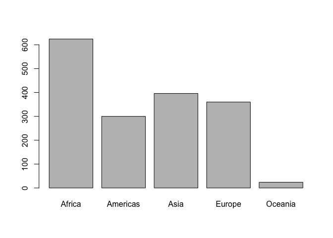

```r
#spread
#way1:plot the data
plot(gapminder$continent)
```

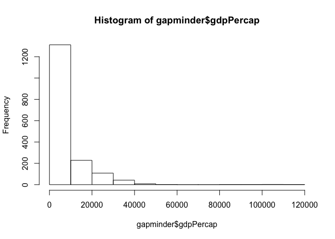

```r
hist(gapminder$gdpPercap)
```

```r
#way2:calculating summary statistics like sd
gapminder %>%
  summarise(sd = sd(gdpPercap))
```

```
## # A tibble: 1 x 1
##         sd
##      <dbl>
## 1 9857.455
```

A2: We can tell this by plotting the data (boxplots or histograms) by using `plot()` and `hist()`, or calculating summary statistics like the standard deviation of that variable.

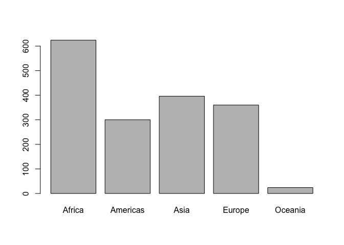

```r
#distribution
plot(gapminder$continent)
```

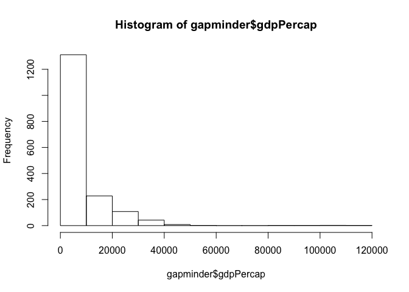

```r
hist(gapminder$gdpPercap)
```

A3: For the distribution, we can also plot the data and figure out the trend of values by using `plot()` and `hist()` functions.

## Explore various plot types

1. A scatterplot of two quantitative variables.
- scatterplot1: This is the scatterplot of `year` and `log10(pop)`. We can add aesthetic mapping of transparency.Then, we can make other plots facetted by `continent` and fit a smoother through the data for each continent.

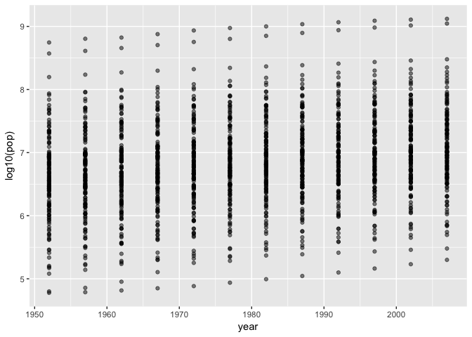

```r
#scatterplot1
p <- ggplot(gapminder, aes(x = year, y = log10(pop)))
p <- p + geom_point(alpha = 0.5)
p
```

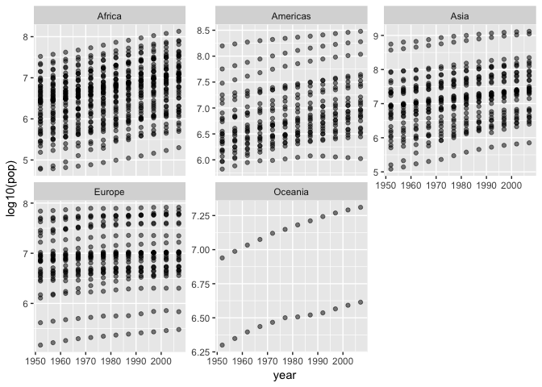

```r
p1 <- p + facet_wrap(~ continent, scales = "free_y")
p1
```

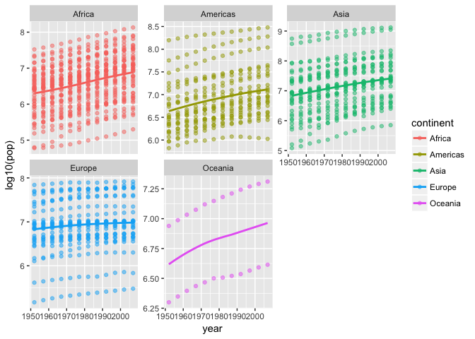

```r
p2 <- p1 + geom_smooth(lwd = 1, se = FALSE) + aes(color = continent)
p2
```

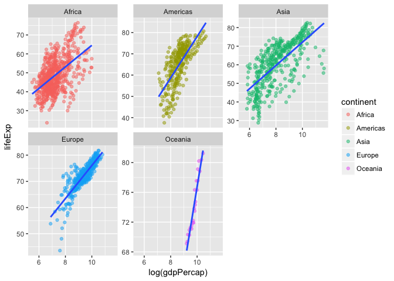

```r
#scatterplot2
p3 <- ggplot(gapminder, aes(x = log(gdpPercap), y = lifeExp))
p3 <- p3 + geom_point(aes(color = continent), alpha = 0.5)
p3 <- p3 + facet_wrap(~ continent, scales = "free_y")
p3 <- p3 + geom_smooth(lwd = 1, se = FALSE, method = 'lm')
p3
```

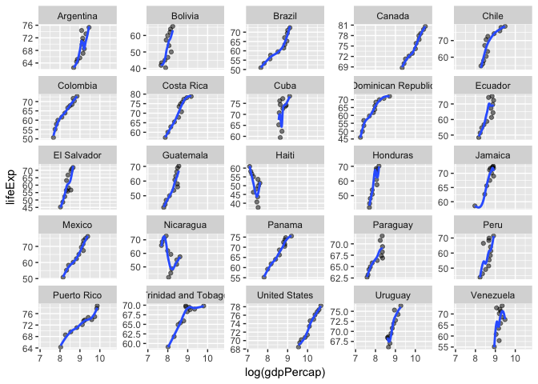

```r
#scatterplot3
Americas <- filter(gapminder, continent == "Americas")
p4 <- ggplot(Americas, aes(x = log(gdpPercap), y = lifeExp))
p4 <- p4 + geom_point(alpha = 0.5)
p4 <- p4 + facet_wrap(~ country, scales = "free_y")
p4 <- p4 + geom_smooth(lwd = 1, se = FALSE)
p4
```

2. A plot of one quantitative variable. Maybe a histogram or densityplot or frequency polygon.
- Make a densityplot of `log10(pop)` by using `density()` and `plot()`.

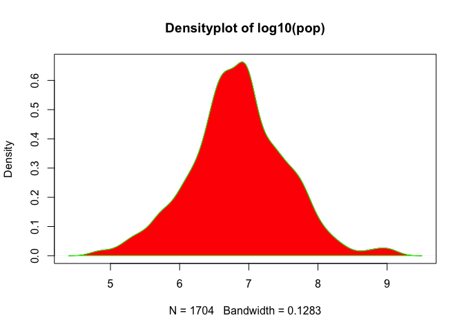

```r
den_pop <- density(log10(gapminder$pop))
plot(den_pop, main = "Densityplot of log10(pop)")
polygon(den_pop, col = "red", border = "green")
```

- Make a histogram of `log10(pop)` by using `hist()`.

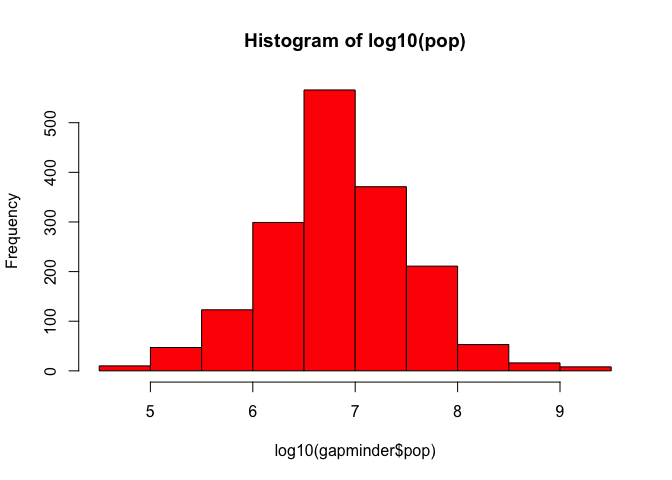

```r
hist(log10(gapminder$pop), col="red", main="Histogram of log10(pop)")
```

3. A plot of one quantitative variable and one categorical. Maybe boxplots for several continents or countries.
- Make a boxplot for `log10(pop)` and `continent`.

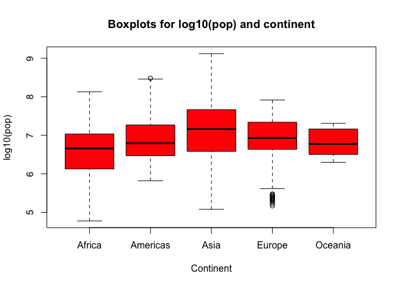

```r
boxplot(log10(pop) ~ continent,data = gapminder,
        main = "Boxplots for log10(pop) and continent",
        xlab = "Continent", ylab = "log10(pop)", col="red")
```

## Use filter(), select() and %>%

Take all entries of Canada occuring from 1950-2010, and select the `year`, and `gdpPercap` columns, then piping into `ggplot()`.

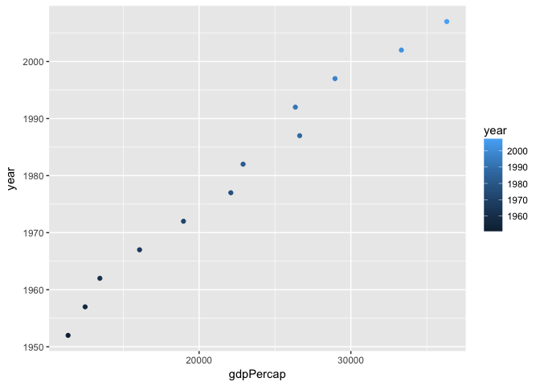

```r
out1 <- gapminder %>%
   filter(country == "Canada",
           year <= 2010, year >= 1950) %>%
    select(year, gdpPercap) %>%
  ggplot(aes(x = gdpPercap, y = year)) + geom_point(aes(color = year))
out1
```

## But I want to do more!

I thought it would be wrong if running the code showing below because we are more likely to use `"%in%"` instead of `"=="`. We cannot get all the data for Rwanda and Afghanistan if we use `"=="`.

```r
filter(gapminder, country == c("Rwanda", "Afghanistan"))
```

```
## # A tibble: 12 x 6
##        country continent  year lifeExp      pop gdpPercap
##         <fctr>    <fctr> <int>   <dbl>    <int>     <dbl>
##  1 Afghanistan      Asia  1957  30.332  9240934  820.8530
##  2 Afghanistan      Asia  1967  34.020 11537966  836.1971
##  3 Afghanistan      Asia  1977  38.438 14880372  786.1134
##  4 Afghanistan      Asia  1987  40.822 13867957  852.3959
##  5 Afghanistan      Asia  1997  41.763 22227415  635.3414
##  6 Afghanistan      Asia  2007  43.828 31889923  974.5803
##  7      Rwanda    Africa  1952  40.000  2534927  493.3239
##  8      Rwanda    Africa  1962  43.000  3051242  597.4731
##  9      Rwanda    Africa  1972  44.600  3992121  590.5807
## 10      Rwanda    Africa  1982  46.218  5507565  881.5706
## 11      Rwanda    Africa  1992  23.599  7290203  737.0686
## 12      Rwanda    Africa  2002  43.413  7852401  785.6538
```

```r
filter(gapminder, country %in% c("Rwanda", "Afghanistan"))
```

```
## # A tibble: 24 x 6
##        country continent  year lifeExp      pop gdpPercap
##         <fctr>    <fctr> <int>   <dbl>    <int>     <dbl>
##  1 Afghanistan      Asia  1952  28.801  8425333  779.4453
##  2 Afghanistan      Asia  1957  30.332  9240934  820.8530
##  3 Afghanistan      Asia  1962  31.997 10267083  853.1007
##  4 Afghanistan      Asia  1967  34.020 11537966  836.1971
##  5 Afghanistan      Asia  1972  36.088 13079460  739.9811
##  6 Afghanistan      Asia  1977  38.438 14880372  786.1134
##  7 Afghanistan      Asia  1982  39.854 12881816  978.0114
##  8 Afghanistan      Asia  1987  40.822 13867957  852.3959
##  9 Afghanistan      Asia  1992  41.674 16317921  649.3414
## 10 Afghanistan      Asia  1997  41.763 22227415  635.3414
## # ... with 14 more rows
```